# TelecomunicationCompanyChurnPredictor

Import Libraries

```python
import pandas as pd
import numpy as np
import seaborn as sns
import matplotlib.pyplot as plt
from sklearn.ensemble import RandomForestClassifier,AdaBoostClassifier
from sklearn.neighbors import KNeighborsClassifier
from sklearn.model_selection import train_test_split
from sklearn import model_selection
from sklearn.svm import SVC
from sklearn.naive_bayes import GaussianNB
from sklearn.metrics import accuracy_score,confusion_matrix
```

Read CSV of the DataSet

```python
data=pd.read_csv("/Users/Lucca/Desktop/DMML_Project/Telco_customer_churn_cleaned.csv.zip")
data.head()
```

|  | customerID | gender | SeniorCitizen | Partner | Dependents | tenure | PhoneService | MultipleLines | InternetService | OnlineSecurity | ... | Streaming Music | Premium Tech Support | Unlimited Data | Total Refunds | Total Extra Data Charges | Total Long Distance Charges | Total Revenue | Satisfaction Score | Customer Status | Churn Category |
| --- | --- | --- | --- | --- | --- | --- | --- | --- | --- | --- | --- | --- | --- | --- | --- | --- | --- | --- | --- | --- | --- |
| 0 | 3668-QPYBK | Male | 0 | No | No | 2 | Yes | No | DSL | Yes | ... | No | No | Yes | 0.0 | 0 | 20.94 | 129.09 | 1 | Churned | Competitor |
| 1 | 9237-HQITU | Female | 0 | No | No | 2 | Yes | No | Fiber optic | No | ... | No | No | Yes | 0.0 | 0 | 18.24 | 169.89 | 2 | Churned | Other |
| 2 | 9305-CDSKC | Female | 0 | No | No | 8 | Yes | Yes | Fiber optic | No | ... | Yes | No | Yes | 0.0 | 0 | 97.20 | 917.70 | 3 | Churned | Other |
| 3 | 7892-POOKP | Female | 0 | Yes | No | 28 | Yes | Yes | Fiber optic | No | ... | Yes | Yes | Yes | 0.0 | 0 | 136.92 | 3182.97 | 3 | Churned | Other |
| 4 | 0280-XJGEX | Male | 0 | No | No | 49 | Yes | Yes | Fiber optic | No | ... | Yes | No | Yes | 0.0 | 0 | 2172.17 | 7208.47 | 1 | Churned | Competitor |

5 rows × 50 columns

Show the data

```python
data
```

|  | customerID | gender | SeniorCitizen | Partner | Dependents | tenure | PhoneService | MultipleLines | InternetService | OnlineSecurity | ... | Streaming Music | Premium Tech Support | Unlimited Data | Total Refunds | Total Extra Data Charges | Total Long Distance Charges | Total Revenue | Satisfaction Score | Customer Status | Churn Category |
| --- | --- | --- | --- | --- | --- | --- | --- | --- | --- | --- | --- | --- | --- | --- | --- | --- | --- | --- | --- | --- | --- |
| 0 | 3668-QPYBK | Male | 0 | No | No | 2 | Yes | No | DSL | Yes | ... | No | No | Yes | 0.00 | 0 | 20.94 | 129.09 | 1 | Churned | Competitor |
| 1 | 9237-HQITU | Female | 0 | No | No | 2 | Yes | No | Fiber optic | No | ... | No | No | Yes | 0.00 | 0 | 18.24 | 169.89 | 2 | Churned | Other |
| 2 | 9305-CDSKC | Female | 0 | No | No | 8 | Yes | Yes | Fiber optic | No | ... | Yes | No | Yes | 0.00 | 0 | 97.20 | 917.70 | 3 | Churned | Other |
| 3 | 7892-POOKP | Female | 0 | Yes | No | 28 | Yes | Yes | Fiber optic | No | ... | Yes | Yes | Yes | 0.00 | 0 | 136.92 | 3182.97 | 3 | Churned | Other |
| 4 | 0280-XJGEX | Male | 0 | No | No | 49 | Yes | Yes | Fiber optic | No | ... | Yes | No | Yes | 0.00 | 0 | 2172.17 | 7208.47 | 1 | Churned | Competitor |
| ... | ... | ... | ... | ... | ... | ... | ... | ... | ... | ... | ... | ... | ... | ... | ... | ... | ... | ... | ... | ... | ... |
| 7038 | 2569-WGERO | Female | 0 | No | No | 72 | Yes | No | No | No internet service | ... | No | No | No | 19.31 | 0 | 1639.44 | 3039.53 | 5 | Stayed | 0 |
| 7039 | 6840-RESVB | Male | 0 | Yes | Yes | 24 | Yes | Yes | DSL | Yes | ... | Yes | Yes | Yes | 48.23 | 0 | 865.20 | 2807.47 | 3 | Stayed | 0 |
| 7040 | 2234-XADUH | Female | 0 | Yes | Yes | 72 | Yes | Yes | Fiber optic | No | ... | Yes | No | Yes | 45.38 | 0 | 2135.52 | 9453.04 | 4 | Stayed | 0 |
| 7041 | 4801-JZAZL | Female | 0 | Yes | Yes | 11 | No | No phone service | DSL | Yes | ... | No | No | Yes | 27.24 | 0 | 0.00 | 319.21 | 4 | Stayed | 0 |
| 7042 | 3186-AJIEK | Male | 0 | No | No | 66 | Yes | No | Fiber optic | Yes | ... | Yes | Yes | Yes | 0.00 | 0 | 2043.36 | 8887.86 | 4 | Stayed | 0 |

7043 rows × 50 columns

Types of the data

```python
data.dtypes
```

```
customerID                            object
gender                                object
SeniorCitizen                          int64
Partner                               object
Dependents                            object
tenure                                 int64
PhoneService                          object
MultipleLines                         object
InternetService                       object
OnlineSecurity                        object
OnlineBackup                          object
DeviceProtection                      object
TechSupport                           object
StreamingTV                           object
StreamingMovies                       object
Contract                              object
PaperlessBilling                      object
PaymentMethod                         object
MonthlyCharges                       float64
TotalCharges                         float64
Churn                                 object
churn_rate                             int64
CLTV                                   int64
Churn Reason                          object
Count                                  int64
Country                               object
State                                 object
City                                  object
Zip Code                               int64
Lat Long                              object
Latitude                             float64
Longitude                            float64
Age                                    int64
Under 30                              object
Married                               object
Referred a Friend                     object
Number of Referrals                    int64
Offer                                 object
Avg Monthly Long Distance Charges    float64
Avg Monthly GB Download                int64
Streaming Music                       object
Premium Tech Support                  object
Unlimited Data                        object
Total Refunds                        float64
Total Extra Data Charges               int64
Total Long Distance Charges          float64
Total Revenue                        float64
Satisfaction Score                     int64
Customer Status                       object
Churn Category                        object
dtype: object
```

See if there are some Nan Value

```python
data.isna().sum(axis=0)
```

```
customerID                              0
gender                                  0
SeniorCitizen                           0
Partner                                 0
Dependents                              0
tenure                                  0
PhoneService                            0
MultipleLines                           0
InternetService                         0
OnlineSecurity                          0
OnlineBackup                            0
DeviceProtection                        0
TechSupport                             0
StreamingTV                             0
StreamingMovies                         0
Contract                                0
PaperlessBilling                        0
PaymentMethod                           0
MonthlyCharges                          0
TotalCharges                            0
Churn                                   0
churn_rate                              0
CLTV                                    0
Churn Reason                         5174
Count                                   0
Country                                 0
State                                   0
City                                    0
Zip Code                                0
Lat Long                                0
Latitude                                0
Longitude                               0
Age                                     0
Under 30                                0
Married                                 0
Referred a Friend                       0
Number of Referrals                     0
Offer                                   0
Avg Monthly Long Distance Charges       0
Avg Monthly GB Download                 0
Streaming Music                         0
Premium Tech Support                    0
Unlimited Data                          0
Total Refunds                           0
Total Extra Data Charges                0
Total Long Distance Charges             0
Total Revenue                           0
Satisfaction Score                      0
Customer Status                         0
Churn Category                          0
dtype: int64
```

drop columns that doesn't metter in this case, because for example CustomerId changes always same as the Latitude and Lontitude of each customer

```python
data.drop(["customerID", "churn_rate", "Churn", "Country", "State", "City", "Zip Code", "Lat Long", "Latitude", "Longitude"], axis = 1, inplace = True)
data.head()
```

|  | gender | SeniorCitizen | Partner | Dependents | tenure | PhoneService | MultipleLines | InternetService | OnlineSecurity | OnlineBackup | ... | Streaming Music | Premium Tech Support | Unlimited Data | Total Refunds | Total Extra Data Charges | Total Long Distance Charges | Total Revenue | Satisfaction Score | Customer Status | Churn Category |
| --- | --- | --- | --- | --- | --- | --- | --- | --- | --- | --- | --- | --- | --- | --- | --- | --- | --- | --- | --- | --- | --- |
| 0 | Male | 0 | No | No | 2 | Yes | No | DSL | Yes | Yes | ... | No | No | Yes | 0.0 | 0 | 20.94 | 129.09 | 1 | Churned | Competitor |
| 1 | Female | 0 | No | No | 2 | Yes | No | Fiber optic | No | No | ... | No | No | Yes | 0.0 | 0 | 18.24 | 169.89 | 2 | Churned | Other |
| 2 | Female | 0 | No | No | 8 | Yes | Yes | Fiber optic | No | No | ... | Yes | No | Yes | 0.0 | 0 | 97.20 | 917.70 | 3 | Churned | Other |
| 3 | Female | 0 | Yes | No | 28 | Yes | Yes | Fiber optic | No | No | ... | Yes | Yes | Yes | 0.0 | 0 | 136.92 | 3182.97 | 3 | Churned | Other |
| 4 | Male | 0 | No | No | 49 | Yes | Yes | Fiber optic | No | Yes | ... | Yes | No | Yes | 0.0 | 0 | 2172.17 | 7208.47 | 1 | Churned | Competitor |

5 rows × 40 columns

I want to proof if the Count has a unique value of all 1 after some intuition taken from the previous table

```python
data["Count"].unique()
```

```
array([1], dtype=int64)
```

dropped because has all 1

```python
data.drop("Count",axis=1,inplace=True)
data
```

|  | gender | SeniorCitizen | Partner | Dependents | tenure | PhoneService | MultipleLines | InternetService | OnlineSecurity | OnlineBackup | ... | Streaming Music | Premium Tech Support | Unlimited Data | Total Refunds | Total Extra Data Charges | Total Long Distance Charges | Total Revenue | Satisfaction Score | Customer Status | Churn Category |
| --- | --- | --- | --- | --- | --- | --- | --- | --- | --- | --- | --- | --- | --- | --- | --- | --- | --- | --- | --- | --- | --- |
| 0 | Male | 0 | No | No | 2 | Yes | No | DSL | Yes | Yes | ... | No | No | Yes | 0.00 | 0 | 20.94 | 129.09 | 1 | Churned | Competitor |
| 1 | Female | 0 | No | No | 2 | Yes | No | Fiber optic | No | No | ... | No | No | Yes | 0.00 | 0 | 18.24 | 169.89 | 2 | Churned | Other |
| 2 | Female | 0 | No | No | 8 | Yes | Yes | Fiber optic | No | No | ... | Yes | No | Yes | 0.00 | 0 | 97.20 | 917.70 | 3 | Churned | Other |
| 3 | Female | 0 | Yes | No | 28 | Yes | Yes | Fiber optic | No | No | ... | Yes | Yes | Yes | 0.00 | 0 | 136.92 | 3182.97 | 3 | Churned | Other |
| 4 | Male | 0 | No | No | 49 | Yes | Yes | Fiber optic | No | Yes | ... | Yes | No | Yes | 0.00 | 0 | 2172.17 | 7208.47 | 1 | Churned | Competitor |
| ... | ... | ... | ... | ... | ... | ... | ... | ... | ... | ... | ... | ... | ... | ... | ... | ... | ... | ... | ... | ... | ... |
| 7038 | Female | 0 | No | No | 72 | Yes | No | No | No internet service | No internet service | ... | No | No | No | 19.31 | 0 | 1639.44 | 3039.53 | 5 | Stayed | 0 |
| 7039 | Male | 0 | Yes | Yes | 24 | Yes | Yes | DSL | Yes | No | ... | Yes | Yes | Yes | 48.23 | 0 | 865.20 | 2807.47 | 3 | Stayed | 0 |
| 7040 | Female | 0 | Yes | Yes | 72 | Yes | Yes | Fiber optic | No | Yes | ... | Yes | No | Yes | 45.38 | 0 | 2135.52 | 9453.04 | 4 | Stayed | 0 |
| 7041 | Female | 0 | Yes | Yes | 11 | No | No phone service | DSL | Yes | No | ... | No | No | Yes | 27.24 | 0 | 0.00 | 319.21 | 4 | Stayed | 0 |
| 7042 | Male | 0 | No | No | 66 | Yes | No | Fiber optic | Yes | No | ... | Yes | Yes | Yes | 0.00 | 0 | 2043.36 | 8887.86 | 4 | Stayed | 0 |

7043 rows × 39 columns

joined now customers has behaviour to be determined because he is joined now, i cant say anything on it,they are not churned or stayed but joined now as new customer

```python
data=data[data["Customer Status"]!="Joined"]
data
```

|  | gender | SeniorCitizen | Partner | Dependents | tenure | PhoneService | MultipleLines | InternetService | OnlineSecurity | OnlineBackup | ... | Streaming Music | Premium Tech Support | Unlimited Data | Total Refunds | Total Extra Data Charges | Total Long Distance Charges | Total Revenue | Satisfaction Score | Customer Status | Churn Category |
| --- | --- | --- | --- | --- | --- | --- | --- | --- | --- | --- | --- | --- | --- | --- | --- | --- | --- | --- | --- | --- | --- |
| 0 | Male | 0 | No | No | 2 | Yes | No | DSL | Yes | Yes | ... | No | No | Yes | 0.00 | 0 | 20.94 | 129.09 | 1 | Churned | Competitor |
| 1 | Female | 0 | No | No | 2 | Yes | No | Fiber optic | No | No | ... | No | No | Yes | 0.00 | 0 | 18.24 | 169.89 | 2 | Churned | Other |
| 2 | Female | 0 | No | No | 8 | Yes | Yes | Fiber optic | No | No | ... | Yes | No | Yes | 0.00 | 0 | 97.20 | 917.70 | 3 | Churned | Other |
| 3 | Female | 0 | Yes | No | 28 | Yes | Yes | Fiber optic | No | No | ... | Yes | Yes | Yes | 0.00 | 0 | 136.92 | 3182.97 | 3 | Churned | Other |
| 4 | Male | 0 | No | No | 49 | Yes | Yes | Fiber optic | No | Yes | ... | Yes | No | Yes | 0.00 | 0 | 2172.17 | 7208.47 | 1 | Churned | Competitor |
| ... | ... | ... | ... | ... | ... | ... | ... | ... | ... | ... | ... | ... | ... | ... | ... | ... | ... | ... | ... | ... | ... |
| 7038 | Female | 0 | No | No | 72 | Yes | No | No | No internet service | No internet service | ... | No | No | No | 19.31 | 0 | 1639.44 | 3039.53 | 5 | Stayed | 0 |
| 7039 | Male | 0 | Yes | Yes | 24 | Yes | Yes | DSL | Yes | No | ... | Yes | Yes | Yes | 48.23 | 0 | 865.20 | 2807.47 | 3 | Stayed | 0 |
| 7040 | Female | 0 | Yes | Yes | 72 | Yes | Yes | Fiber optic | No | Yes | ... | Yes | No | Yes | 45.38 | 0 | 2135.52 | 9453.04 | 4 | Stayed | 0 |
| 7041 | Female | 0 | Yes | Yes | 11 | No | No phone service | DSL | Yes | No | ... | No | No | Yes | 27.24 | 0 | 0.00 | 319.21 | 4 | Stayed | 0 |
| 7042 | Male | 0 | No | No | 66 | Yes | No | Fiber optic | Yes | No | ... | Yes | Yes | Yes | 0.00 | 0 | 2043.36 | 8887.86 | 4 | Stayed | 0 |

6589 rows × 39 columns

conversion to 1 and 0 from categorical value

```python
boolean_features=["Partner", "Dependents", "PhoneService", "MultipleLines", "OnlineSecurity", "OnlineBackup", "StreamingTV", "StreamingMovies", "DeviceProtection", "TechSupport", "PaperlessBilling", "Streaming Music", "Under 30", "Married", "Referred a Friend", "Unlimited Data", "Premium Tech Support"]
for feature in boolean_features:
    data[feature]=data[feature].map({"Yes":1,"No":0,"No phone service": 0, "No internet service": 0})
data["Customer Status"]=data["Customer Status"].map({"Stayed": 0, "Churned": 1})
data
```

[output not shown]

[output cut: 53 more lines]

[output not shown]

|  | gender | SeniorCitizen | Partner | Dependents | tenure | PhoneService | MultipleLines | InternetService | OnlineSecurity | OnlineBackup | ... | Streaming Music | Premium Tech Support | Unlimited Data | Total Refunds | Total Extra Data Charges | Total Long Distance Charges | Total Revenue | Satisfaction Score | Customer Status | Churn Category |
| --- | --- | --- | --- | --- | --- | --- | --- | --- | --- | --- | --- | --- | --- | --- | --- | --- | --- | --- | --- | --- | --- |
| 0 | Male | 0 | 0 | 0 | 2 | 1 | 0 | DSL | 1 | 1 | ... | 0 | 0 | 1 | 0.00 | 0 | 20.94 | 129.09 | 1 | 1 | Competitor |
| 1 | Female | 0 | 0 | 0 | 2 | 1 | 0 | Fiber optic | 0 | 0 | ... | 0 | 0 | 1 | 0.00 | 0 | 18.24 | 169.89 | 2 | 1 | Other |
| 2 | Female | 0 | 0 | 0 | 8 | 1 | 1 | Fiber optic | 0 | 0 | ... | 1 | 0 | 1 | 0.00 | 0 | 97.20 | 917.70 | 3 | 1 | Other |
| 3 | Female | 0 | 1 | 0 | 28 | 1 | 1 | Fiber optic | 0 | 0 | ... | 1 | 1 | 1 | 0.00 | 0 | 136.92 | 3182.97 | 3 | 1 | Other |
| 4 | Male | 0 | 0 | 0 | 49 | 1 | 1 | Fiber optic | 0 | 1 | ... | 1 | 0 | 1 | 0.00 | 0 | 2172.17 | 7208.47 | 1 | 1 | Competitor |
| ... | ... | ... | ... | ... | ... | ... | ... | ... | ... | ... | ... | ... | ... | ... | ... | ... | ... | ... | ... | ... | ... |
| 7038 | Female | 0 | 0 | 0 | 72 | 1 | 0 | No | 0 | 0 | ... | 0 | 0 | 0 | 19.31 | 0 | 1639.44 | 3039.53 | 5 | 0 | 0 |
| 7039 | Male | 0 | 1 | 1 | 24 | 1 | 1 | DSL | 1 | 0 | ... | 1 | 1 | 1 | 48.23 | 0 | 865.20 | 2807.47 | 3 | 0 | 0 |
| 7040 | Female | 0 | 1 | 1 | 72 | 1 | 1 | Fiber optic | 0 | 1 | ... | 1 | 0 | 1 | 45.38 | 0 | 2135.52 | 9453.04 | 4 | 0 | 0 |
| 7041 | Female | 0 | 1 | 1 | 11 | 0 | 0 | DSL | 1 | 0 | ... | 0 | 0 | 1 | 27.24 | 0 | 0.00 | 319.21 | 4 | 0 | 0 |
| 7042 | Male | 0 | 0 | 0 | 66 | 1 | 0 | Fiber optic | 1 | 0 | ... | 1 | 1 | 1 | 0.00 | 0 | 2043.36 | 8887.86 | 4 | 0 | 0 |

6589 rows × 39 columns

Check if the conversion has some error or it is gone all well

```python
data.isna().sum(axis=0)
```

```
gender                                  0
SeniorCitizen                           0
Partner                                 0
Dependents                              0
tenure                                  0
PhoneService                            0
MultipleLines                           0
InternetService                         0
OnlineSecurity                          0
OnlineBackup                            0
DeviceProtection                        0
TechSupport                             0
StreamingTV                             0
StreamingMovies                         0
Contract                                0
PaperlessBilling                        0
PaymentMethod                           0
MonthlyCharges                          0
TotalCharges                            0
CLTV                                    0
Churn Reason                         4720
Age                                     0
Under 30                                0
Married                                 0
Referred a Friend                       0
Number of Referrals                     0
Offer                                   0
Avg Monthly Long Distance Charges       0
Avg Monthly GB Download                 0
Streaming Music                         0
Premium Tech Support                    0
Unlimited Data                          0
Total Refunds                           0
Total Extra Data Charges                0
Total Long Distance Charges             0
Total Revenue                           0
Satisfaction Score                      0
Customer Status                         0
Churn Category                          0
dtype: int64
```

data types of the data

```python
data.dtypes
```

```
gender                                object
SeniorCitizen                          int64
Partner                                int64
Dependents                             int64
tenure                                 int64
PhoneService                           int64
MultipleLines                          int64
InternetService                       object
OnlineSecurity                         int64
OnlineBackup                           int64
DeviceProtection                       int64
TechSupport                            int64
StreamingTV                            int64
StreamingMovies                        int64
Contract                              object
PaperlessBilling                       int64
PaymentMethod                         object
MonthlyCharges                       float64
TotalCharges                         float64
CLTV                                   int64
Churn Reason                          object
Age                                    int64
Under 30                               int64
Married                                int64
Referred a Friend                      int64
Number of Referrals                    int64
Offer                                 object
Avg Monthly Long Distance Charges    float64
Avg Monthly GB Download                int64
Streaming Music                        int64
Premium Tech Support                   int64
Unlimited Data                         int64
Total Refunds                        float64
Total Extra Data Charges               int64
Total Long Distance Charges          float64
Total Revenue                        float64
Satisfaction Score                     int64
Customer Status                        int64
Churn Category                        object
dtype: object
```

See the different churn reason of customer

```python
data["Churn Reason"].value_counts()
```

```
Attitude of support person                   192
Competitor offered higher download speeds    189
Competitor offered more data                 162
Don't know                                   154
Competitor made better offer                 140
Attitude of service provider                 135
Competitor had better devices                130
Network reliability                          103
Product dissatisfaction                      102
Price too high                                98
Service dissatisfaction                       89
Lack of self-service on Website               88
Extra data charges                            57
Moved                                         53
Limited range of services                     44
Long distance charges                         44
Lack of affordable download/upload speed      44
Poor expertise of phone support               20
Poor expertise of online support              19
Deceased                                       6
Name: Churn Reason, dtype: int64
```

the category death and moved are caused by major forces and is not important to the analysis baceuse death the customer was with us in the end and moved bacause our service cannot go with him in other countries

```python
data=data[~data["Churn Reason"].isin(["Deceased","Moved"])]
data.head()
```

|  | gender | SeniorCitizen | Partner | Dependents | tenure | PhoneService | MultipleLines | InternetService | OnlineSecurity | OnlineBackup | ... | Streaming Music | Premium Tech Support | Unlimited Data | Total Refunds | Total Extra Data Charges | Total Long Distance Charges | Total Revenue | Satisfaction Score | Customer Status | Churn Category |
| --- | --- | --- | --- | --- | --- | --- | --- | --- | --- | --- | --- | --- | --- | --- | --- | --- | --- | --- | --- | --- | --- |
| 0 | Male | 0 | 0 | 0 | 2 | 1 | 0 | DSL | 1 | 1 | ... | 0 | 0 | 1 | 0.0 | 0 | 20.94 | 129.09 | 1 | 1 | Competitor |
| 4 | Male | 0 | 0 | 0 | 49 | 1 | 1 | Fiber optic | 0 | 1 | ... | 1 | 0 | 1 | 0.0 | 0 | 2172.17 | 7208.47 | 1 | 1 | Competitor |
| 5 | Female | 0 | 1 | 1 | 10 | 1 | 0 | DSL | 0 | 0 | ... | 0 | 1 | 1 | 0.0 | 0 | 94.10 | 622.45 | 1 | 1 | Competitor |
| 6 | Male | 1 | 0 | 0 | 1 | 0 | 0 | DSL | 0 | 0 | ... | 0 | 0 | 0 | 0.0 | 20 | 0.00 | 59.65 | 3 | 1 | Competitor |
| 7 | Male | 0 | 0 | 0 | 1 | 1 | 0 | No | 0 | 0 | ... | 0 | 0 | 0 | 0.0 | 0 | 33.58 | 53.73 | 1 | 1 | Competitor |

5 rows × 39 columns

See every churn category of customer

```python
data["Churn Category"].value_counts()
```

```
0                  4720
Competitor          834
Attitude            314
Dissatisfaction     303
Price               211
Other               148
Name: Churn Category, dtype: int64
```

See how are distribuited the long distance charges

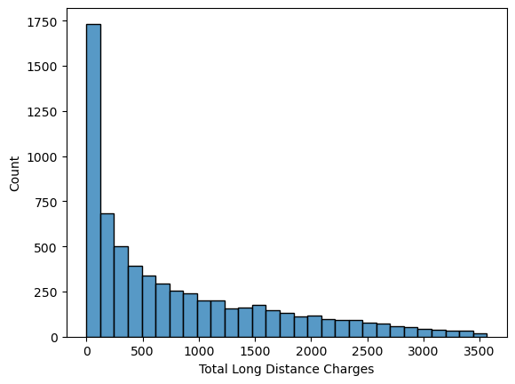

```python
sns.histplot(data["Total Long Distance Charges"])
```

we can see the major part of customers charges a few credit, with increase of charge less are people that charge a lot of money

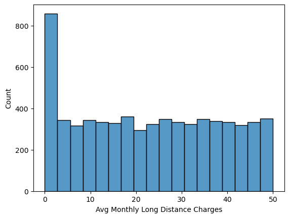

```python
sns.histplot(data["Avg Monthly Long Distance Charges"])
```

try to proof if the total long time charge is given by the avg mothly charge multiplied by the tenure of the customer, because of math relationship (time stayed*avg month charge = total charges of the customer in the time)

```python
((data["Avg Monthly Long Distance Charges"] * data["tenure"] - data["Total Long Distance Charges"]).abs() < 1e-7).value_counts()
```

```
True     6521
False       9
dtype: int64
```

we can drop it because the math i can say that AVG month charge* tenure = Total charges because we can see that the error rate is 9/6521

```python
data.drop("Total Long Distance Charges", axis = 1, inplace = True)
```

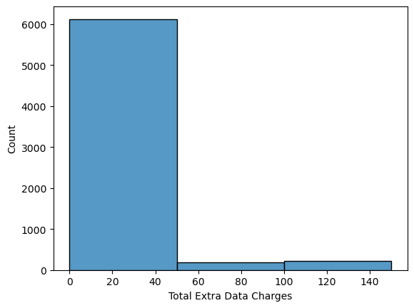

```python
sns.histplot(data["Total Extra Data Charges"], bins = 3)
```

```python
(data["Total Extra Data Charges"] > 0).value_counts()
```

```
False    5852
True      678
Name: Total Extra Data Charges, dtype: int64
```

```python
data["Has Extra Data Charges"] = (data["Total Extra Data Charges"] > 0).astype("float")
data.drop("Total Extra Data Charges", axis = 1, inplace = True)
```

```python
col_corr=["tenure","MonthlyCharges","TotalCharges","Total Refunds","CLTV","Number of Referrals","Avg Monthly Long Distance Charges","Avg Monthly GB Download","Total Revenue"]
data[col_corr].head()
correlation_matrix = data[col_corr].corr()
```

analysis of numerical features and dropping of these feature that exceed the threshold of -0.75 to 0.75 con correlation score

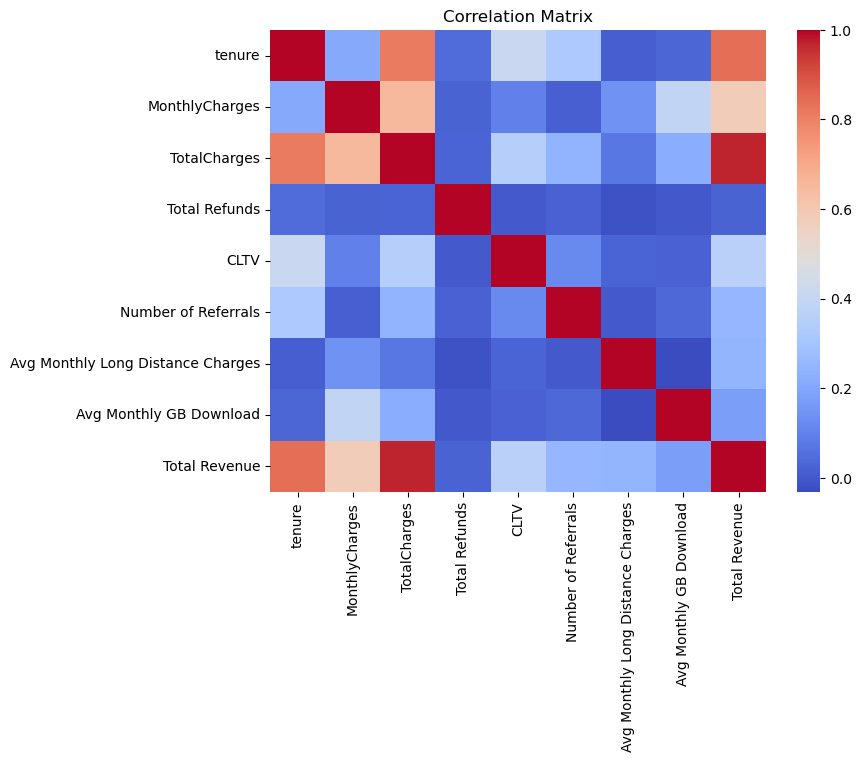

```python
plt.figure(figsize=(8, 6))
sns.heatmap(correlation_matrix, cmap='coolwarm', fmt=".2f")
plt.title('Correlation Matrix')
plt.show()
```

```python
data.drop("TotalCharges", axis = 1, inplace = True)
```

married or have a partner we can use have a partner bacauseit includes married people

```python
data["Married"].equals(data["Partner"])
```

```
True
```

```python
data.drop("Married",inplace=True,axis=1)
```

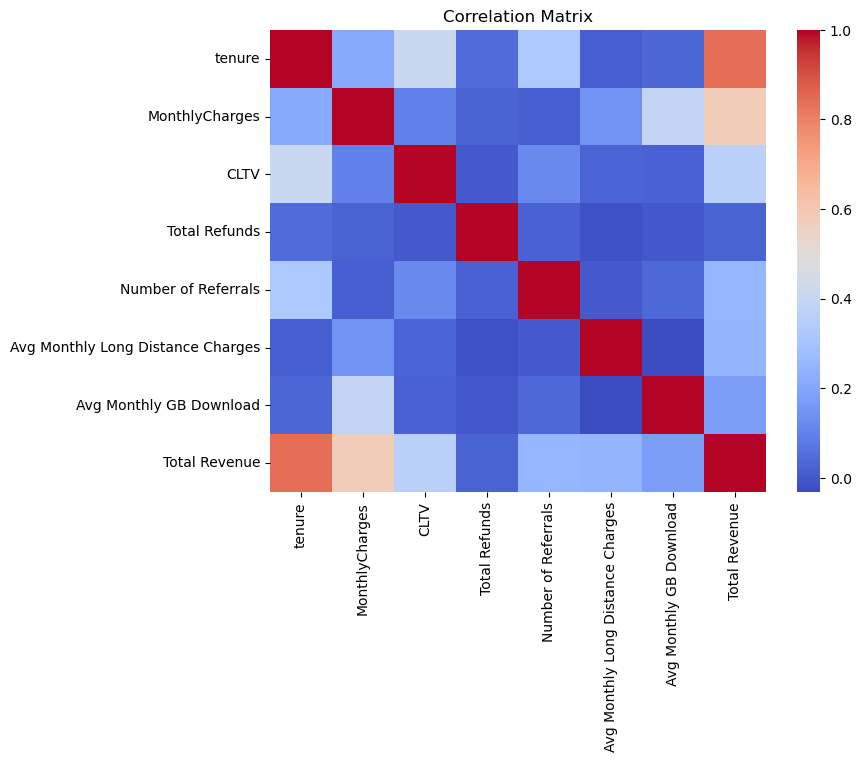

```python
col_corr=["tenure","MonthlyCharges","CLTV","Total Refunds","Number of Referrals","Avg Monthly Long Distance Charges","Avg Monthly GB Download","Total Revenue"]
correlation_matrix=data[col_corr].corr()
plt.figure(figsize=(8, 6))
sns.heatmap(correlation_matrix, cmap='coolwarm', fmt=".2f")
plt.title('Correlation Matrix')
plt.show()
```

```python
data = pd.concat([data, pd.get_dummies(data[["InternetService", "Offer", "PaymentMethod", "Contract"]])], axis = 1)
data.drop(["InternetService", "Offer", "PaymentMethod", "Contract"], axis = 1, inplace = True)
data["gender"]=data["gender"].map({"Male":0,"Female":1})
data
```

|  | gender | SeniorCitizen | Partner | Dependents | tenure | PhoneService | MultipleLines | OnlineSecurity | OnlineBackup | DeviceProtection | ... | Offer_Offer C | Offer_Offer D | Offer_Offer E | PaymentMethod_Bank transfer (automatic) | PaymentMethod_Credit card (automatic) | PaymentMethod_Electronic check | PaymentMethod_Mailed check | Contract_Month-to-month | Contract_One year | Contract_Two year |
| --- | --- | --- | --- | --- | --- | --- | --- | --- | --- | --- | --- | --- | --- | --- | --- | --- | --- | --- | --- | --- | --- |
| 0 | 0 | 0 | 0 | 0 | 2 | 1 | 0 | 1 | 1 | 0 | ... | 0 | 0 | 0 | 0 | 0 | 0 | 1 | 1 | 0 | 0 |
| 4 | 0 | 0 | 0 | 0 | 49 | 1 | 1 | 0 | 1 | 1 | ... | 0 | 0 | 0 | 1 | 0 | 0 | 0 | 1 | 0 | 0 |
| 5 | 1 | 0 | 1 | 1 | 10 | 1 | 0 | 0 | 0 | 1 | ... | 0 | 0 | 0 | 0 | 1 | 0 | 0 | 1 | 0 | 0 |
| 6 | 0 | 1 | 0 | 0 | 1 | 0 | 0 | 0 | 0 | 1 | ... | 0 | 0 | 0 | 0 | 0 | 1 | 0 | 1 | 0 | 0 |
| 7 | 0 | 0 | 0 | 0 | 1 | 1 | 0 | 0 | 0 | 0 | ... | 0 | 0 | 0 | 0 | 0 | 0 | 1 | 1 | 0 | 0 |
| ... | ... | ... | ... | ... | ... | ... | ... | ... | ... | ... | ... | ... | ... | ... | ... | ... | ... | ... | ... | ... | ... |
| 7038 | 1 | 0 | 0 | 0 | 72 | 1 | 0 | 0 | 0 | 0 | ... | 0 | 0 | 0 | 1 | 0 | 0 | 0 | 0 | 0 | 1 |
| 7039 | 0 | 0 | 1 | 1 | 24 | 1 | 1 | 1 | 0 | 1 | ... | 1 | 0 | 0 | 0 | 0 | 0 | 1 | 0 | 1 | 0 |
| 7040 | 1 | 0 | 1 | 1 | 72 | 1 | 1 | 0 | 1 | 1 | ... | 0 | 0 | 0 | 0 | 1 | 0 | 0 | 0 | 1 | 0 |
| 7041 | 1 | 0 | 1 | 1 | 11 | 0 | 0 | 1 | 0 | 0 | ... | 0 | 0 | 0 | 0 | 0 | 1 | 0 | 1 | 0 | 0 |
| 7042 | 0 | 0 | 0 | 0 | 66 | 1 | 0 | 1 | 0 | 1 | ... | 0 | 0 | 0 | 1 | 0 | 0 | 0 | 0 | 0 | 1 |

6530 rows × 48 columns

```python
data.dtypes
```

```
gender                                       int64
SeniorCitizen                                int64
Partner                                      int64
Dependents                                   int64
tenure                                       int64
PhoneService                                 int64
MultipleLines                                int64
OnlineSecurity                               int64
OnlineBackup                                 int64
DeviceProtection                             int64
TechSupport                                  int64
StreamingTV                                  int64
StreamingMovies                              int64
PaperlessBilling                             int64
MonthlyCharges                             float64
CLTV                                         int64
Churn Reason                                object
Age                                          int64
Under 30                                     int64
Referred a Friend                            int64
Number of Referrals                          int64
Avg Monthly Long Distance Charges          float64
Avg Monthly GB Download                      int64
Streaming Music                              int64
Premium Tech Support                         int64
Unlimited Data                               int64
Total Refunds                              float64
Total Revenue                              float64
Satisfaction Score                           int64
Customer Status                              int64
Churn Category                              object
Has Extra Data Charges                     float64
InternetService_DSL                          uint8
InternetService_Fiber optic                  uint8
InternetService_No                           uint8
Offer_None                                   uint8
Offer_Offer A                                uint8
Offer_Offer B                                uint8
Offer_Offer C                                uint8
Offer_Offer D                                uint8
Offer_Offer E                                uint8
PaymentMethod_Bank transfer (automatic)      uint8
PaymentMethod_Credit card (automatic)        uint8
PaymentMethod_Electronic check               uint8
PaymentMethod_Mailed check                   uint8
Contract_Month-to-month                      uint8
Contract_One year                            uint8
Contract_Two year                            uint8
dtype: object
```

ML MODEL

then we split the data attribute in X and Y Y is the target to predict and is given by stayed and churned

```python
X=data.drop(["Churn Reason", "Customer Status", "Churn Category"], axis = 1)
Y=data["Customer Status"]
```

the result of preprocessing

```python
data.head()
```

|  | gender | SeniorCitizen | Partner | Dependents | tenure | PhoneService | MultipleLines | OnlineSecurity | OnlineBackup | DeviceProtection | ... | Offer_Offer C | Offer_Offer D | Offer_Offer E | PaymentMethod_Bank transfer (automatic) | PaymentMethod_Credit card (automatic) | PaymentMethod_Electronic check | PaymentMethod_Mailed check | Contract_Month-to-month | Contract_One year | Contract_Two year |
| --- | --- | --- | --- | --- | --- | --- | --- | --- | --- | --- | --- | --- | --- | --- | --- | --- | --- | --- | --- | --- | --- |
| 0 | 0 | 0 | 0 | 0 | 2 | 1 | 0 | 1 | 1 | 0 | ... | 0 | 0 | 0 | 0 | 0 | 0 | 1 | 1 | 0 | 0 |
| 4 | 0 | 0 | 0 | 0 | 49 | 1 | 1 | 0 | 1 | 1 | ... | 0 | 0 | 0 | 1 | 0 | 0 | 0 | 1 | 0 | 0 |
| 5 | 1 | 0 | 1 | 1 | 10 | 1 | 0 | 0 | 0 | 1 | ... | 0 | 0 | 0 | 0 | 1 | 0 | 0 | 1 | 0 | 0 |
| 6 | 0 | 1 | 0 | 0 | 1 | 0 | 0 | 0 | 0 | 1 | ... | 0 | 0 | 0 | 0 | 0 | 1 | 0 | 1 | 0 | 0 |
| 7 | 0 | 0 | 0 | 0 | 1 | 1 | 0 | 0 | 0 | 0 | ... | 0 | 0 | 0 | 0 | 0 | 0 | 1 | 1 | 0 | 0 |

5 rows × 48 columns

Input columns and their data type

```python
display(X.dtypes)
```

```
gender                                       int64
SeniorCitizen                                int64
Partner                                      int64
Dependents                                   int64
tenure                                       int64
PhoneService                                 int64
MultipleLines                                int64
OnlineSecurity                               int64
OnlineBackup                                 int64
DeviceProtection                             int64
TechSupport                                  int64
StreamingTV                                  int64
StreamingMovies                              int64
PaperlessBilling                             int64
MonthlyCharges                             float64
CLTV                                         int64
Age                                          int64
Under 30                                     int64
Referred a Friend                            int64
Number of Referrals                          int64
Avg Monthly Long Distance Charges          float64
Avg Monthly GB Download                      int64
Streaming Music                              int64
Premium Tech Support                         int64
Unlimited Data                               int64
Total Refunds                              float64
Total Revenue                              float64
Satisfaction Score                           int64
Has Extra Data Charges                     float64
InternetService_DSL                          uint8
InternetService_Fiber optic                  uint8
InternetService_No                           uint8
Offer_None                                   uint8
Offer_Offer A                                uint8
Offer_Offer B                                uint8
Offer_Offer C                                uint8
Offer_Offer D                                uint8
Offer_Offer E                                uint8
PaymentMethod_Bank transfer (automatic)      uint8
PaymentMethod_Credit card (automatic)        uint8
PaymentMethod_Electronic check               uint8
PaymentMethod_Mailed check                   uint8
Contract_Month-to-month                      uint8
Contract_One year                            uint8
Contract_Two year                            uint8
dtype: object
```

output data type

```python
display(Y.dtypes)
```

```
dtype('int64')
```

Distribution of the 2 class

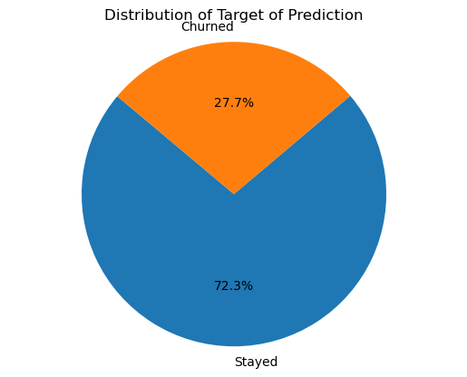

```python
plt.pie(Y.value_counts(),labels=['Stayed','Churned'],autopct='%1.1f%%', startangle=140)
plt.axis('equal')
plt.title("Distribution of Target of Prediction")

plt.show()
```

models that we chose to train and evaluate

```python
from sklearn.pipeline import Pipeline
from sklearn.preprocessing import MinMaxScaler
from sklearn.feature_selection import SelectKBest,f_classif
models=[]
models.append(("RandomForest",Pipeline([("scaler",MinMaxScaler()),("feature selection",SelectKBest(score_func=f_classif)),("classifier",RandomForestClassifier())])))
models.append(("Naive Bayes",Pipeline([("scaler",MinMaxScaler()),("feature selection",SelectKBest(score_func=f_classif)),("classifier",GaussianNB())])))
models.append(("KNeighbors",Pipeline([("scaler",MinMaxScaler()),("feature selection",SelectKBest(score_func=f_classif)),("classifier",KNeighborsClassifier())])))
models.append(("SVM",Pipeline([("scaler",MinMaxScaler()),("feature selection",SelectKBest(score_func=f_classif)),("classifier",SVC(probability=True))])))
models.append(("AdaBoost",Pipeline([("scaler",MinMaxScaler()),("feature selection",SelectKBest(score_func=f_classif)),("classifier",AdaBoostClassifier())])))
```

```python
col=["Classifier","Accuracy Mean","Precision Mean","Recall Mean","F1 Score Mean","ROC AUC Mean"]
model_results=pd.DataFrame(columns=col)
```

```python
from sklearn.metrics import accuracy_score,f1_score,precision_score,recall_score,roc_auc_score
```

Cross validation with 10 fold

```python
kfold=model_selection.StratifiedKFold(n_splits=10,random_state=42,shuffle=True)
accuracy_RF=[]
accuracy_NB=[]
accuracy_KNN=[]
accuracy_SVM=[]
accuracy_ADA=[]
precision_RF=[]
precision_NB=[]
precision_KNN=[]
precision_SVM=[]
precision_ADA=[]
recall_RF=[]
recall_NB=[]
recall_KNN=[]
recall_SVM=[]
recall_ADA=[]
f1_RF=[]
f1_NB=[]
f1_KNN=[]
f1_SVM=[]
f1_ADA=[]
rocauc_RF=[]
rocauc_NB=[]
rocauc_KNN=[]
rocauc_SVM=[]
rocauc_ADA=[]
overall_true_RF=[]
overall_predict_RF=[]
overall_predict_auc_RF=[]
overall_true_NB=[]
overall_predict_NB=[]
overall_predict_auc_NB=[]
overall_true_KNN=[]
overall_predict_KNN=[]
overall_predict_auc_KNN=[]
overall_true_SVM=[]
overall_predict_SVM=[]
overall_predict_auc_SVM=[]
overall_true_ADA=[]
overall_predict_ADA=[]
overall_predict_auc_ADA=[]
for train,val in kfold.split(X,Y):
    X_tr = X.iloc[train]
    Y_tr = Y.iloc[train]
    X_val = X.iloc[val]
    Y_val = Y.iloc[val]
    j=0
    for name,model in models:
        model.fit(X_tr,Y_tr)
        pred=model.predict(X_val)
        if j==0:
            precision_RF.append(precision_score(Y_val,pred))
            recall_RF.append(recall_score(Y_val,pred))
            f1_RF.append(f1_score(Y_val,pred))
            accuracy_RF.append(accuracy_score(Y_val,pred))
            pred_proba=model.predict_proba(X_val)[:, 1]
            rocauc_RF.append(roc_auc_score(Y_val,pred_proba))
            overall_true_RF.extend(Y_val)
            overall_predict_RF.extend(pred)
            overall_predict_auc_RF.extend(pred_proba)
        elif j==1:
            precision_NB.append(precision_score(Y_val,pred))
            recall_NB.append(recall_score(Y_val,pred))
            f1_NB.append(f1_score(Y_val,pred))
            accuracy_NB.append(accuracy_score(Y_val,pred))
            pred_proba=model.predict_proba(X_val)[:, 1]
            rocauc_NB.append(roc_auc_score(Y_val,pred_proba))
            overall_true_NB.extend(Y_val)
            overall_predict_NB.extend(pred)
            overall_predict_auc_NB.extend(pred_proba)
        elif j==2:
            precision_KNN.append(precision_score(Y_val,pred))
            recall_KNN.append(recall_score(Y_val,pred))
            f1_KNN.append(f1_score(Y_val,pred))
            accuracy_KNN.append(accuracy_score(Y_val,pred))
            pred_proba=model.predict_proba(X_val)[:, 1]
            rocauc_KNN.append(roc_auc_score(Y_val,pred_proba))
            overall_true_KNN.extend(Y_val)
            overall_predict_KNN.extend(pred)
            overall_predict_auc_KNN.extend(pred_proba)
        elif j==3:
            precision_SVM.append(precision_score(Y_val,pred))
            recall_SVM.append(recall_score(Y_val,pred))
            f1_SVM.append(f1_score(Y_val,pred))
            accuracy_SVM.append(accuracy_score(Y_val,pred))
            pred_proba=model.predict_proba(X_val)[:, 1]
            rocauc_SVM.append(roc_auc_score(Y_val,pred_proba))
            overall_true_SVM.extend(Y_val)
            overall_predict_SVM.extend(pred)
            overall_predict_auc_SVM.extend(pred_proba)
        else:
            precision_ADA.append(precision_score(Y_val,pred))
            recall_ADA.append(recall_score(Y_val,pred))
            f1_ADA.append(f1_score(Y_val,pred))
            accuracy_ADA.append(accuracy_score(Y_val,pred))
            pred_proba=model.predict_proba(X_val)[:, 1]
            rocauc_ADA.append(roc_auc_score(Y_val,pred_proba))
            overall_true_ADA.extend(Y_val)
            overall_predict_ADA.extend(pred)
            overall_predict_auc_ADA.extend(pred_proba)
        j+=1
    f1_AB1=np.array(f1_ADA)
    f1_RF1=np.array(f1_RF)
    f1_KNN1=np.array(f1_KNN)
    f1_SVM1=np.array(f1_SVM)
    f1_NB1=np.array(f1_NB)
h=0
Y_true=Y_val
X_for_test=X_val
for name,model in models:
    if name=="RandomForest":
        model_results.loc[h]=[name,round(np.array(accuracy_RF).mean()*100,2),round(np.array(precision_RF).mean()*100,2),round(np.array(recall_RF).mean()*100,2),round(np.array(f1_RF).mean()*100,2),round(np.array(rocauc_RF).mean()*100,2)]
    elif name=="Naive Bayes":
        model_results.loc[h]=[name,round(np.array(accuracy_NB).mean()*100,2),round(np.array(precision_NB).mean()*100,2),round(np.array(recall_NB).mean()*100,2),round(np.array(f1_NB).mean()*100,2),round(np.array(rocauc_NB).mean()*100,2)]
    elif name=="KNeighbors":
        model_results.loc[h]=[name,round(np.array(accuracy_KNN).mean()*100,2),round(np.array(precision_KNN).mean()*100,2),round(np.array(recall_KNN).mean()*100,2),round(np.array(f1_KNN).mean()*100,2),round(np.array(rocauc_KNN).mean()*100,2)]
    elif name=="SVM":
        model_results.loc[h]=[name,round(np.array(accuracy_SVM).mean()*100,2),round(np.array(precision_SVM).mean()*100,2),round(np.array(recall_SVM).mean()*100,2),round(np.array(f1_SVM).mean()*100,2),round(np.array(rocauc_SVM).mean()*100,2)]
    else:
        model_results.loc[h]=[name,round(np.array(accuracy_ADA).mean()*100,2),round(np.array(precision_ADA).mean()*100,2),round(np.array(recall_ADA).mean()*100,2),round(np.array(f1_ADA).mean()*100,2),round(np.array(rocauc_ADA).mean()*100,2)]
    h+=1
```

Clssification report of models

```python
model_results
```

|  | Classifier | Accuracy Mean | Precision Mean | Recall Mean | F1 Score Mean | ROC AUC Mean |
| --- | --- | --- | --- | --- | --- | --- |
| 0 | RandomForest | 95.68 | 94.96 | 89.17 | 91.96 | 98.28 |
| 1 | Naive Bayes | 87.83 | 72.83 | 89.50 | 80.30 | 94.50 |
| 2 | KNeighbors | 95.27 | 95.03 | 87.51 | 91.10 | 96.83 |
| 3 | SVM | 95.16 | 95.30 | 86.85 | 90.86 | 98.18 |
| 4 | AdaBoost | 96.34 | 97.81 | 88.78 | 93.07 | 99.06 |

```
Random Forest
```

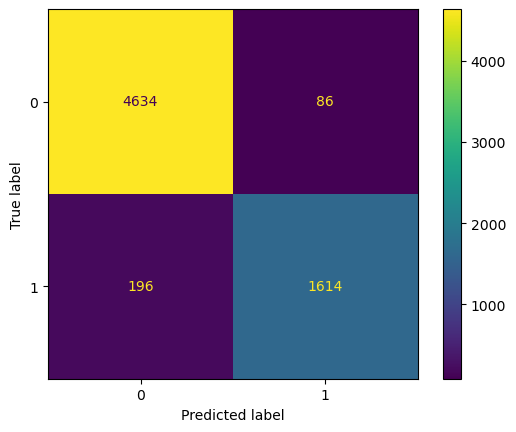

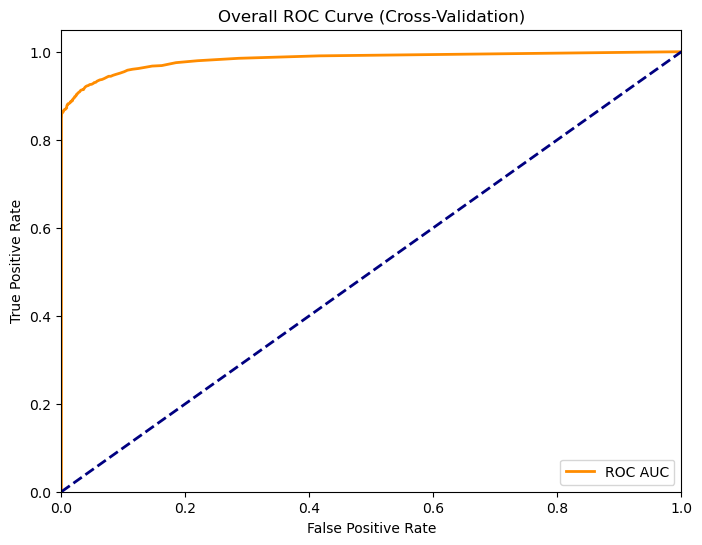

```
Naive Bayes
```

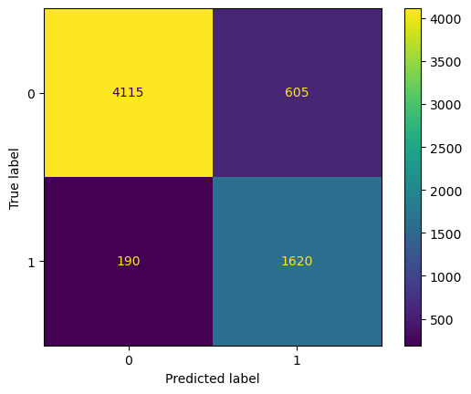

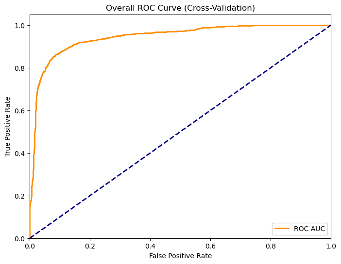

```
KNN
```

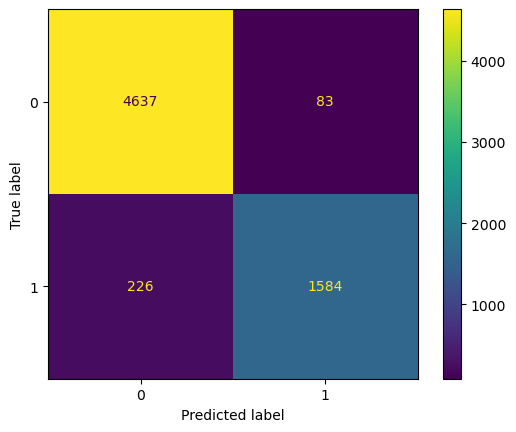

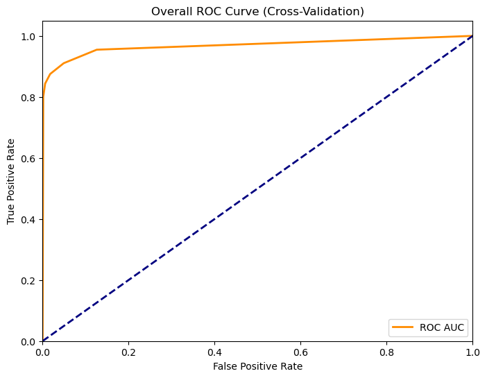

```
SVC
```

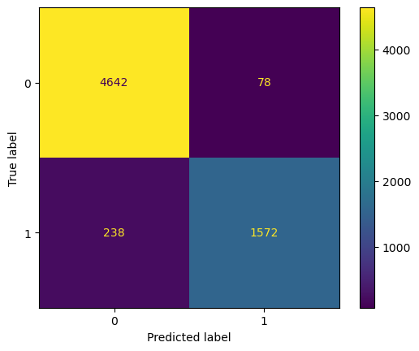

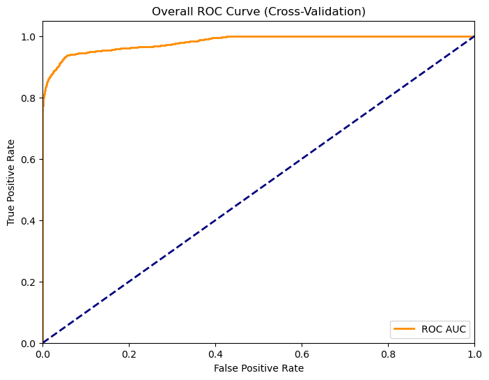

```
ADA
```

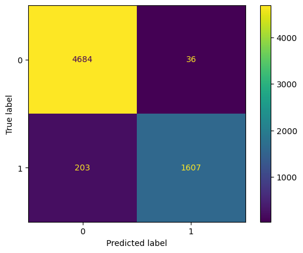

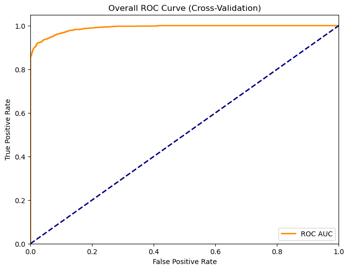

```python
from sklearn.metrics import ConfusionMatrixDisplay,roc_curve

print("Random Forest")
overall_fpr, overall_tpr, _ = roc_curve(overall_true_RF, overall_predict_auc_RF)
ConfusionMatrixDisplay(confusion_matrix=confusion_matrix(overall_true_RF,overall_predict_RF)).plot()
plt.figure(figsize=(8, 6))
plt.plot(overall_fpr, overall_tpr, color='darkorange', lw=2, label='ROC AUC')
plt.plot([0, 1], [0, 1], color='navy', lw=2, linestyle='--')
plt.xlim([0.0, 1.0])
plt.ylim([0.0, 1.05])
plt.xlabel('False Positive Rate')
plt.ylabel('True Positive Rate')
plt.title('Overall ROC Curve (Cross-Validation)')
plt.legend(loc='lower right')
plt.show()
print("Naive Bayes")
overall_fpr, overall_tpr, _ = roc_curve(overall_true_NB, overall_predict_auc_NB)
ConfusionMatrixDisplay(confusion_matrix=confusion_matrix(overall_true_NB,overall_predict_NB)).plot()
plt.figure(figsize=(8, 6))
plt.plot(overall_fpr, overall_tpr, color='darkorange', lw=2, label='ROC AUC')
plt.plot([0, 1], [0, 1], color='navy', lw=2, linestyle='--')
plt.xlim([0.0, 1.0])
plt.ylim([0.0, 1.05])
plt.xlabel('False Positive Rate')
plt.ylabel('True Positive Rate')
plt.title('Overall ROC Curve (Cross-Validation)')
plt.legend(loc='lower right')
plt.show()
print("KNN")
overall_fpr, overall_tpr, _ = roc_curve(overall_true_KNN, overall_predict_auc_KNN)
ConfusionMatrixDisplay(confusion_matrix=confusion_matrix(overall_true_KNN,overall_predict_KNN)).plot()
plt.figure(figsize=(8, 6))
plt.plot(overall_fpr, overall_tpr, color='darkorange', lw=2, label='ROC AUC')
plt.plot([0, 1], [0, 1], color='navy', lw=2, linestyle='--')
plt.xlim([0.0, 1.0])
plt.ylim([0.0, 1.05])
plt.xlabel('False Positive Rate')
plt.ylabel('True Positive Rate')
plt.title('Overall ROC Curve (Cross-Validation)')
plt.legend(loc='lower right')
plt.show()
print("SVC")
overall_fpr, overall_tpr, _ = roc_curve(overall_true_SVM, overall_predict_auc_SVM)
ConfusionMatrixDisplay(confusion_matrix=confusion_matrix(overall_true_SVM,overall_predict_SVM)).plot()
plt.figure(figsize=(8, 6))
plt.plot(overall_fpr, overall_tpr, color='darkorange', lw=2, label='ROC AUC')
plt.plot([0, 1], [0, 1], color='navy', lw=2, linestyle='--')
plt.xlim([0.0, 1.0])
plt.ylim([0.0, 1.05])
plt.xlabel('False Positive Rate')
plt.ylabel('True Positive Rate')
plt.title('Overall ROC Curve (Cross-Validation)')
plt.legend(loc='lower right')
plt.show()
print("ADA")
overall_fpr, overall_tpr, _ = roc_curve(overall_true_ADA, overall_predict_auc_ADA)
ConfusionMatrixDisplay(confusion_matrix=confusion_matrix(overall_true_ADA,overall_predict_ADA)).plot()
plt.figure(figsize=(8, 6))
plt.plot(overall_fpr, overall_tpr, color='darkorange', lw=2, label='ROC AUC')
plt.plot([0, 1], [0, 1], color='navy', lw=2, linestyle='--')
plt.xlim([0.0, 1.0])
plt.ylim([0.0, 1.05])
plt.xlabel('False Positive Rate')
plt.ylabel('True Positive Rate')
plt.title('Overall ROC Curve (Cross-Validation)')
plt.legend(loc='lower right')
plt.show()
```

wilcoxon statistic test

```python
from scipy.stats import wilcoxon
_, p_valueRFSVM = wilcoxon(f1_RF1, f1_SVM1)
_, p_valueRFADA = wilcoxon(f1_RF1, f1_AB1)
_, p_valueSVMADA = wilcoxon(f1_SVM1, f1_AB1)
_, p_valueKNNADA = wilcoxon(f1_KNN1, f1_AB1)
_, p_valueKNNSVM = wilcoxon(f1_KNN1, f1_SVM1)
_, p_valueKNNRF = wilcoxon(f1_KNN1, f1_RF1)
print(p_valueSVMADA)
print(p_valueRFADA)
print(p_valueRFSVM)
print(p_valueKNNADA)
print(p_valueKNNSVM)
print(p_valueKNNRF)
if p_valueSVMADA<0.05:
    print("Ada over SVM")
if p_valueRFADA<0.05:
    print("RF over ADA")
if p_valueRFSVM<0.05:
    print("RF over SVM")
if p_valueKNNADA<0.05:
    print("ADA over KNN")
if p_valueKNNSVM<0.05:
    print("KNN over SVM")
if p_valueKNNRF<0.05:
    print("RF over KNN")
```

```
0.001953125
0.010862224704815628
0.048828125
0.001953125
0.625
0.009765625
Ada over SVM
RF over ADA
RF over SVM
ADA over KNN
RF over KNN
```

try to resample because as we have already seen in the pie graph classes are imbalanced with 30-70% of the data, so we try to perform a oversampling operation with SMOTE

```python
from imblearn.over_sampling import SMOTE
```

construction of pipelines of chosen models with oversampling

```python
from imblearn.pipeline import Pipeline as ImbPipeline
models_resampled=[]
models_resampled.append(("RandomForest",ImbPipeline([("sampling",SMOTE(random_state=123)),("scaler",MinMaxScaler()),("feature selection",SelectKBest(score_func=f_classif)),("classifier",RandomForestClassifier())])))
models_resampled.append(("Naive Bayes",ImbPipeline([("sampling",SMOTE(random_state=123)),("scaler",MinMaxScaler()),("feature selection",SelectKBest(score_func=f_classif)),("classifier",GaussianNB())])))
models_resampled.append(("KNeighbors",ImbPipeline([("sampling",SMOTE(random_state=123)),("scaler",MinMaxScaler()),("classifier",KNeighborsClassifier())])))
models_resampled.append(("SVM",ImbPipeline([("sampling",SMOTE(random_state=123)),("scaler",MinMaxScaler()),("feature selection",SelectKBest(score_func=f_classif)),("classifier",SVC(probability=True))])))
models_resampled.append(("AdaBoost",ImbPipeline([("sampling",SMOTE(random_state=123)),("scaler",MinMaxScaler()),("feature selection",SelectKBest(score_func=f_classif)),("classifier",AdaBoostClassifier())])))
```

build the dataframe to put result about classifiers

```python
col=["Classifier","Accuracy Mean","Precision Mean","Recall Mean","F1 Score Mean","ROC AUC Mean"]
model_results_resampled=pd.DataFrame(columns=col)
```

Function that evaluates the models with SMOTE

```python
def eval_cross_validation(classifiers,skf,X,Y,model_res):

    accuracy_RF=[]
    accuracy_NB=[]
    accuracy_KNN=[]
    accuracy_SVM=[]
    accuracy_ADA=[]
    precision_RF=[]
    precision_NB=[]
    precision_KNN=[]
    precision_SVM=[]
    precision_ADA=[]
    recall_RF=[]
    recall_NB=[]
    recall_KNN=[]
    recall_SVM=[]
    recall_ADA=[]
    f1_RF=[]
    f1_NB=[]
    f1_KNN=[]
    f1_SVM=[]
    f1_ADA=[]
    rocauc_RF=[]
    rocauc_NB=[]
    rocauc_KNN=[]
    rocauc_SVM=[]
    rocauc_ADA=[]
    overall_true_RF1=[]
    overall_predict_RF1=[]
    overall_predict_auc_RF1=[]
    overall_true_NB1=[]
    overall_predict_NB1=[]
    overall_predict_auc_NB1=[]
    overall_true_KNN1=[]
    overall_predict_KNN1=[]
    overall_predict_auc_KNN1=[]
    overall_true_SVM1=[]
    overall_predict_SVM1=[]
    overall_predict_auc_SVM1=[]
    overall_true_ADA1=[]
    overall_predict_ADA1=[]
    overall_predict_auc_ADA1=[]
    for train,val in skf.split(X,Y):
        X_tr = X.iloc[train]
        Y_tr = Y.iloc[train]
        X_val = X.iloc[val]
        Y_val = Y.iloc[val]
        j=0
        for name,model in classifiers:
            model.fit(X_tr,Y_tr)
            pred=model.predict(X_val)
            if j==0:
                precision_RF.append(precision_score(Y_val,pred))
                recall_RF.append(recall_score(Y_val,pred))
                f1_RF.append(f1_score(Y_val,pred))
                accuracy_RF.append(accuracy_score(Y_val,pred))
                pred_proba1=model.predict_proba(X_val)[:, 1]
                rocauc_RF.append(roc_auc_score(Y_val,pred_proba1))
                overall_true_RF1.extend(Y_val)
                overall_predict_RF1.extend(pred)
                overall_predict_auc_RF1.extend(pred_proba1)
            elif j==1:
                pred_proba1=model.predict_proba(X_val)[:, 1]
                precision_NB.append(precision_score(Y_val,pred))
                recall_NB.append(recall_score(Y_val,pred))
                f1_NB.append(f1_score(Y_val,pred))
                accuracy_NB.append(accuracy_score(Y_val,pred))
                rocauc_NB.append(roc_auc_score(Y_val,pred_proba1))
                overall_true_NB1.extend(Y_val)
                overall_predict_NB1.extend(pred)
                overall_predict_auc_NB1.extend(pred_proba1)
            elif j==2:
                precision_KNN.append(precision_score(Y_val,pred))
                recall_KNN.append(recall_score(Y_val,pred))
                f1_KNN.append(f1_score(Y_val,pred))
                accuracy_KNN.append(accuracy_score(Y_val,pred))
                pred_proba1=model.predict_proba(X_val)[:, 1]
                rocauc_KNN.append(roc_auc_score(Y_val,pred_proba1))
                overall_true_KNN1.extend(Y_val)
                overall_predict_KNN1.extend(pred)
                overall_predict_auc_KNN1.extend(pred_proba1)
            elif j==3:
                precision_SVM.append(precision_score(Y_val,pred))
                recall_SVM.append(recall_score(Y_val,pred))
                f1_SVM.append(f1_score(Y_val,pred))
                accuracy_SVM.append(accuracy_score(Y_val,pred))
                pred_proba1=model.predict_proba(X_val)[:, 1]
                rocauc_SVM.append(roc_auc_score(Y_val,pred_proba1))
                overall_true_SVM1.extend(Y_val)
                overall_predict_SVM1.extend(pred)
                overall_predict_auc_SVM1.extend(pred_proba1)
            else:
                precision_ADA.append(precision_score(Y_val,pred))
                recall_ADA.append(recall_score(Y_val,pred))
                f1_ADA.append(f1_score(Y_val,pred))
                accuracy_ADA.append(accuracy_score(Y_val,pred))
                pred_proba1=model.predict_proba(X_val)[:, 1]
                rocauc_ADA.append(roc_auc_score(Y_val,pred_proba1))
                overall_true_ADA1.extend(Y_val)
                overall_predict_ADA1.extend(pred)
                overall_predict_auc_ADA1.extend(pred_proba1)
            j+=1
        f1_AB2=np.array(f1_ADA)
        f1_RF2=np.array(f1_RF)
        f1_KNN2=np.array(f1_KNN)
        f1_SVM2=np.array(f1_SVM)
        f1_NB2=np.array(f1_NB)
    h=0
    for name,model in classifiers:
        if name=="RandomForest":
            model_res.loc[h]=[name,round(np.array(accuracy_RF).mean()*100,2),round(np.array(precision_RF).mean()*100,2),round(np.array(recall_RF).mean()*100,2),round(np.array(f1_RF).mean()*100,2),round(np.array(rocauc_RF).mean()*100,2)]
        elif name=="Naive Bayes":
            model_res.loc[h]=[name,round(np.array(accuracy_NB).mean()*100,2),round(np.array(precision_NB).mean()*100,2),round(np.array(recall_NB).mean()*100,2),round(np.array(f1_NB).mean()*100,2),round(np.array(rocauc_NB).mean()*100,2)]
        elif name=="KNeighbors":
            model_res.loc[h]=[name,round(np.array(accuracy_KNN).mean()*100,2),round(np.array(precision_KNN).mean()*100,2),round(np.array(recall_KNN).mean()*100,2),round(np.array(f1_KNN).mean()*100,2),round(np.array(rocauc_KNN).mean()*100,2)]
        elif name=="SVM":
            model_res.loc[h]=[name,round(np.array(accuracy_SVM).mean()*100,2),round(np.array(precision_SVM).mean()*100,2),round(np.array(recall_SVM).mean()*100,2),round(np.array(f1_SVM).mean()*100,2),round(np.array(rocauc_SVM).mean()*100,2)]
        else:
            model_res.loc[h]=[name,round(np.array(accuracy_ADA).mean()*100,2),round(np.array(precision_ADA).mean()*100,2),round(np.array(recall_ADA).mean()*100,2),round(np.array(f1_ADA).mean()*100,2),round(np.array(rocauc_ADA).mean()*100,2)]
        h+=1
    return model_res,f1_RF2,f1_NB2,f1_KNN2,f1_SVM2,f1_AB2,classifiers,overall_true_RF1,overall_predict_RF1,overall_true_NB1,overall_predict_NB1,overall_true_KNN1,overall_predict_KNN1,overall_true_SVM1,overall_predict_SVM1,overall_true_ADA1,overall_predict_ADA1,overall_predict_auc_RF1,overall_predict_auc_NB1,overall_predict_auc_KNN1,overall_predict_auc_SVM1,overall_predict_auc_ADA1
```

call of the function and the results of classifiers

```python
skf=model_selection.StratifiedKFold(n_splits=10,shuffle=True,random_state=42)
model_results_resampled_returned,f1_RF2,f1_NB2,f1_KNN2,f1_SVM2,f1_AB2,classifiers,overall_true_RF1,overall_predict_RF1,overall_true_NB1,overall_predict_NB1,overall_true_KNN1,overall_predict_KNN1,overall_true_SVM1,overall_predict_SVM1,overall_true_ADA1,overall_predict_ADA1,overall_predict_auc_RF1,overall_predict_auc_NB1,overall_predict_auc_KNN1,overall_predict_auc_SVM1,overall_predict_auc_ADA1=eval_cross_validation(models_resampled,skf,X,Y,model_results_resampled)
```

output of the results of classifiers

```python
model_results_resampled_returned.head()
```

|  | Classifier | Accuracy Mean | Precision Mean | Recall Mean | F1 Score Mean | ROC AUC Mean |
| --- | --- | --- | --- | --- | --- | --- |
| 0 | RandomForest | 94.81 | 91.24 | 90.00 | 90.57 | 98.20 |
| 1 | Naive Bayes | 85.74 | 70.45 | 83.81 | 76.53 | 93.01 |
| 2 | KNeighbors | 83.02 | 66.72 | 77.46 | 71.67 | 88.06 |
| 3 | SVM | 95.04 | 91.33 | 90.77 | 91.03 | 98.77 |
| 4 | AdaBoost | 96.19 | 96.58 | 89.45 | 92.85 | 99.17 |

```
Random Forest
```

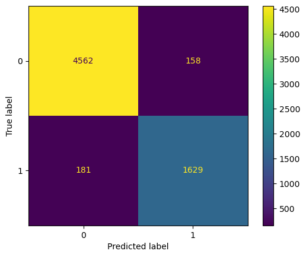

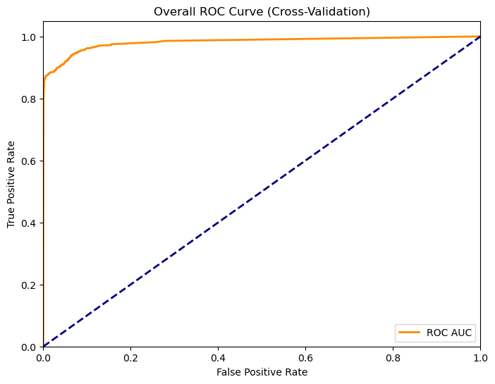

```
Naive Bayes
```

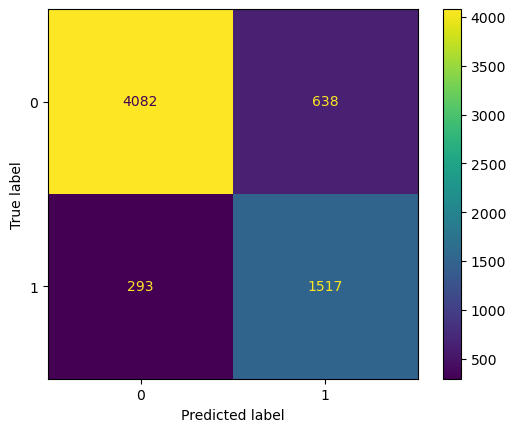

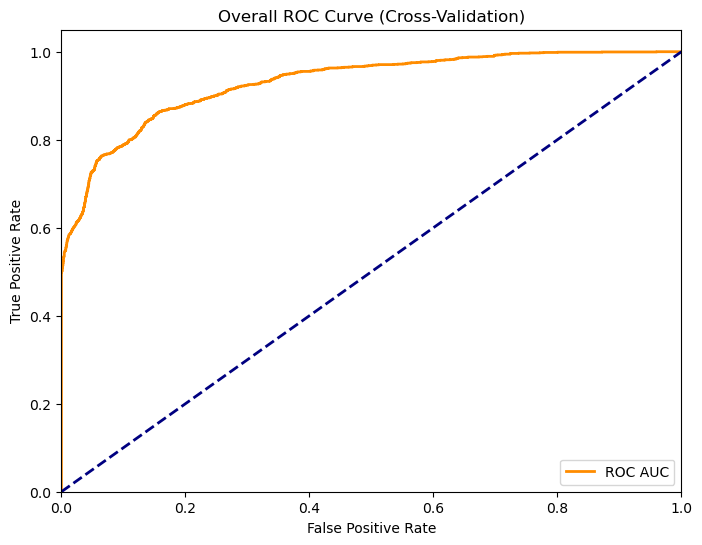

```
KNN
```

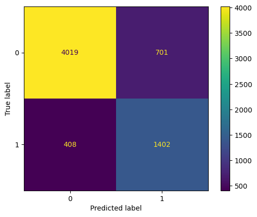

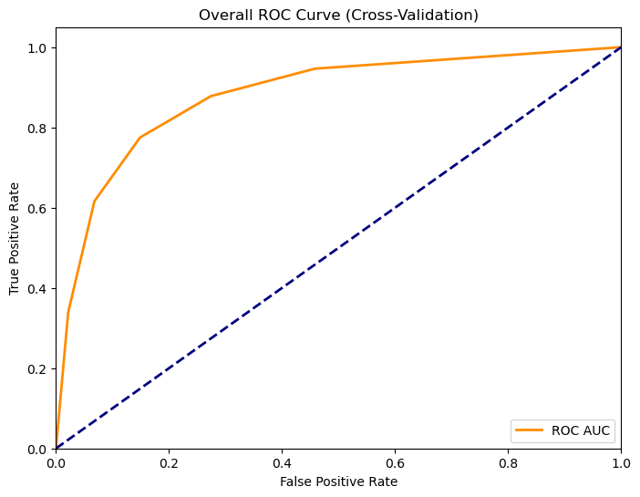

```
SVC
```

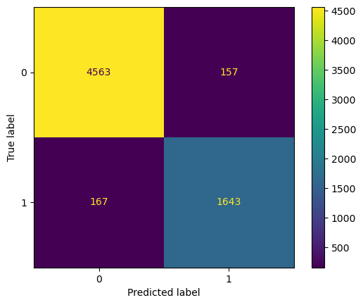

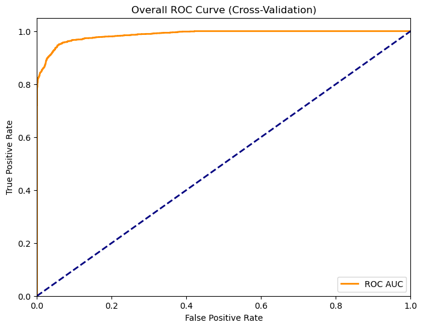

```
ADA
```

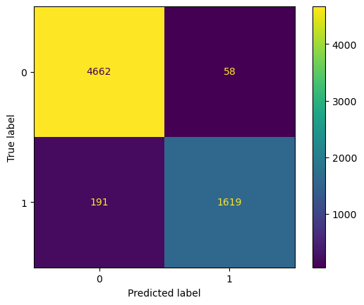

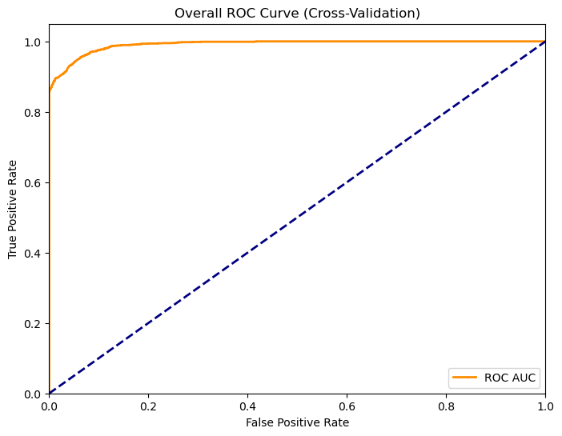

```python
print("Random Forest")
overall_fpr, overall_tpr, _ = roc_curve(overall_true_RF1, overall_predict_auc_RF1)
ConfusionMatrixDisplay(confusion_matrix=confusion_matrix(overall_true_RF1,overall_predict_RF1)).plot()
plt.figure(figsize=(8, 6))
plt.plot(overall_fpr, overall_tpr, color='darkorange', lw=2, label='ROC AUC')
plt.plot([0, 1], [0, 1], color='navy', lw=2, linestyle='--')
plt.xlim([0.0, 1.0])
plt.ylim([0.0, 1.05])
plt.xlabel('False Positive Rate')
plt.ylabel('True Positive Rate')
plt.title('Overall ROC Curve (Cross-Validation)')
plt.legend(loc='lower right')
plt.show()
print("Naive Bayes")
overall_fpr, overall_tpr, _ = roc_curve(overall_true_NB1, overall_predict_auc_NB1)
ConfusionMatrixDisplay(confusion_matrix=confusion_matrix(overall_true_NB1,overall_predict_NB1)).plot()
plt.figure(figsize=(8, 6))
plt.plot(overall_fpr, overall_tpr, color='darkorange', lw=2, label='ROC AUC')
plt.plot([0, 1], [0, 1], color='navy', lw=2, linestyle='--')
plt.xlim([0.0, 1.0])
plt.ylim([0.0, 1.05])
plt.xlabel('False Positive Rate')
plt.ylabel('True Positive Rate')
plt.title('Overall ROC Curve (Cross-Validation)')
plt.legend(loc='lower right')
plt.show()
print("KNN")
overall_fpr, overall_tpr, _ = roc_curve(overall_true_KNN1, overall_predict_auc_KNN1)
ConfusionMatrixDisplay(confusion_matrix=confusion_matrix(overall_true_KNN1,overall_predict_KNN1)).plot()
plt.figure(figsize=(8, 6))
plt.plot(overall_fpr, overall_tpr, color='darkorange', lw=2, label='ROC AUC')
plt.plot([0, 1], [0, 1], color='navy', lw=2, linestyle='--')
plt.xlim([0.0, 1.0])
plt.ylim([0.0, 1.05])
plt.xlabel('False Positive Rate')
plt.ylabel('True Positive Rate')
plt.title('Overall ROC Curve (Cross-Validation)')
plt.legend(loc='lower right')
plt.show()
print("SVC")
overall_fpr, overall_tpr, _ = roc_curve(overall_true_SVM1, overall_predict_auc_SVM1)
ConfusionMatrixDisplay(confusion_matrix=confusion_matrix(overall_true_SVM1,overall_predict_SVM1)).plot()
plt.figure(figsize=(8, 6))
plt.plot(overall_fpr, overall_tpr, color='darkorange', lw=2, label='ROC AUC')
plt.plot([0, 1], [0, 1], color='navy', lw=2, linestyle='--')
plt.xlim([0.0, 1.0])
plt.ylim([0.0, 1.05])
plt.xlabel('False Positive Rate')
plt.ylabel('True Positive Rate')
plt.title('Overall ROC Curve (Cross-Validation)')
plt.legend(loc='lower right')
plt.show()
print("ADA")
overall_fpr, overall_tpr, _ = roc_curve(overall_true_ADA1, overall_predict_auc_ADA1)
ConfusionMatrixDisplay(confusion_matrix=confusion_matrix(overall_true_ADA1,overall_predict_ADA1)).plot()
plt.figure(figsize=(8, 6))
plt.plot(overall_fpr, overall_tpr, color='darkorange', lw=2, label='ROC AUC')
plt.plot([0, 1], [0, 1], color='navy', lw=2, linestyle='--')
plt.xlim([0.0, 1.0])
plt.ylim([0.0, 1.05])
plt.xlabel('False Positive Rate')
plt.ylabel('True Positive Rate')
plt.title('Overall ROC Curve (Cross-Validation)')
plt.legend(loc='lower right')
plt.show()
```

evaluation of models using wilcoxon statistical test

```python
_, p_valueRFSVM = wilcoxon(f1_RF2, f1_SVM2)
_, p_valueRFADA = wilcoxon(f1_RF2, f1_AB2)
_, p_valueSVMADA = wilcoxon(f1_SVM2, f1_AB2)
print(p_valueSVMADA)
print(p_valueRFADA)
print(p_valueRFSVM)
if p_valueSVMADA<0.05:
    print("Ada over SVM")
if p_valueRFADA<0.05:
    print("RF over ADA")
if p_valueRFSVM<0.05:
    print("RF over SVM")
```

```
0.001953125
0.001953125
0.375
Ada over SVM
RF over ADA
```

Evaluation of classifiers before and after oversampling with SMOTE

```python
_,p_valueRFResampled=wilcoxon(f1_RF1,f1_RF2)
_,p_valueSVMResampled=wilcoxon(f1_SVM1,f1_SVM2)
_,p_valueABResampled=wilcoxon(f1_AB1,f1_AB2)
_,p_valueKNNResampled=wilcoxon(f1_KNN1,f1_KNN2)
_,p_valueNBResampled=wilcoxon(f1_NB1,f1_NB2)
display(p_valueRFResampled)
print(p_valueSVMResampled)
print(p_valueABResampled)
print(p_valueNBResampled)
print(p_valueKNNResampled)
```

```
0.005859375
```

```
0.845703125
0.275390625
0.001953125
0.001953125
```